# Assignment 6 Team 8

Team 8

10/17/2021

# Assignment Question

`Load Flights.csv, Airlines.csv, Airports.csv from LumiNUS. Run the codes shared in class to construct columns: SCHEDULED_DEPARTURE_TIME, ACTUAL_DEPARTURE_TIME, WHEELS_OFF_TIME, WHEELS_ON_TIME, SCHEDULED_ARRIVAL_TIME, ACTUAL_ARRIVAL_TIME.

1. Clean whatever flight problem you may identify.
2. develop proper visualization to answer the following questions: Which airline to choose or avoid when travelling? Which airport to choose or avoid when travelling? What is the seasonal effect on flight performance? How to visualise the flight on map?

You may ask your own question and produce insightful visualisation to address it. `

# Data Cleaning

```r
library(dplyr)
```

```r
flights <- read.csv("flights.csv")
airports <- read.csv("airports.csv")
airlines <- read.csv("airlines.csv")
```

```r
#prof's code
flights$date <- paste(flights$YEAR,flights$MONTH,flights$DAY,sep = "-")

flights$SCHEDULED_DEPARTURE1 <- substr(as.POSIXct(sprintf("%04.0f", flights$SCHEDULED_DEPARTURE), format='%H%M'), 12, 19)
flights$SCHEDULED_DEPARTURE_TIME <- strptime(paste(flights$date,flights$SCHEDULED_DEPARTURE1),format='%Y-%m-%d %H:%M:%S')

flights$DEPARTURE_TIME1 <- substr(as.POSIXct(sprintf("%04.0f", flights$DEPARTURE_TIME), format='%H%M'), 12, 19)
flights$ACTUAL_DEPARTURE_TIME <- strptime(paste(flights$date,flights$DEPARTURE_TIME1),format='%Y-%m-%d %H:%M:%S')

flights$WHEELS_OFF1 <- substr(as.POSIXct(sprintf("%04.0f", flights$WHEELS_OFF), format='%H%M'), 12, 19)
flights$WHEELS_OFF_TIME <- strptime(paste(flights$date,flights$WHEELS_OFF1),format='%Y-%m-%d %H:%M:%S')

flights$WHEELS_ON1 <- substr(as.POSIXct(sprintf("%04.0f", flights$WHEELS_ON), format='%H%M'), 12, 19)
flights$WHEELS_ON_TIME <-  strptime(paste(flights$date,flights$WHEELS_ON1),format='%Y-%m-%d %H:%M:%S')

flights$SCHEDULED_ARRIVAL1 <- substr(as.POSIXct(sprintf("%04.0f", flights$SCHEDULED_ARRIVAL), format='%H%M'), 12, 19)
flights$SCHEDULED_ARRIVAL_TIME <- strptime(paste(flights$date,flights$SCHEDULED_ARRIVAL1),format='%Y-%m-%d %H:%M:%S')

flights$ARRIVAL_TIME1 <- substr(as.POSIXct(sprintf("%04.0f", flights$ARRIVAL_TIME), format='%H%M'), 12, 19)
flights$ACTUAL_ARRIVAL_TIME <- strptime(paste(flights$date,flights$ARRIVAL_TIME1),format='%Y-%m-%d %H:%M:%S')
```

# Cleaning flights problem we identifed.

```r
#cleaning instructions from email
flights$WHEELS_ON_TIME <- flights$WHEELS_OFF_TIME + as.difftime(flights$AIR_TIME, units="mins")
flights$ACTUAL_ARRIVAL_TIME <- flights$WHEELS_ON_TIME + as.difftime(flights$TAXI_IN, units="mins")
```

```r
#change NA to 0 in delay columns (if applicable)

flights$AIR_SYSTEM_DELAY <- ifelse(is.na(flights$AIR_SYSTEM_DELAY), ifelse(flights$ARRIVAL_DELAY <= 0 & flights$CANCELLED != 1, 0, NA), flights$AIR_SYSTEM_DELAY)

flights$SECURITY_DELAY <- ifelse(is.na(flights$SECURITY_DELAY), ifelse(flights$ARRIVAL_DELAY <= 0 & flights$CANCELLED != 1, 0, NA), flights$SECURITY_DELAY)

flights$AIRLINE_DELAY <- ifelse(is.na(flights$AIRLINE_DELAY), ifelse(flights$ARRIVAL_DELAY <= 0 & flights$CANCELLED != 1, 0, NA), flights$AIRLINE_DELAY)

flights$LATE_AIRCRAFT_DELAY <- ifelse(is.na(flights$LATE_AIRCRAFT_DELAY), ifelse(flights$ARRIVAL_DELAY <= 0 & flights$CANCELLED != 1, 0, NA), flights$LATE_AIRCRAFT_DELAY)

flights$WEATHER_DELAY <- ifelse(is.na(flights$WEATHER_DELAY), ifelse(flights$ARRIVAL_DELAY <= 0 & flights$CANCELLED != 1, 0, NA), flights$WEATHER_DELAY)
```

```r
#fix logical errors
for (i in 1:nrow(flights)){
  if (!is.na(flights$WHEELS_OFF_TIME[i]) & !is.na(flights$ACTUAL_DEPARTURE_TIME[i])){
    if (flights$ACTUAL_DEPARTURE_TIME[i] > flights$WHEELS_OFF_TIME[i]){
      flights$WHEELS_OFF_TIME[i] <- flights$ACTUAL_DEPARTURE_TIME[i] + as.difftime(1, units="days")
    }
  }

  if (!is.na(flights$WHEELS_OFF_TIME[i]) & !is.na(flights$WHEELS_ON_TIME[i])){
    if (flights$WHEELS_OFF_TIME[i] > flights$WHEELS_ON_TIME[i]){
        flights$WHEELS_ON_TIME[i] <- flights$WHEELS_ON_TIME[i] + as.difftime(1, units="days")
    }
  }

  if (!is.na(flights$ACTUAL_ARRIVAL_TIME[i]) & !is.na(flights$WHEELS_ON_TIME[i])){
    if (flights$WHEELS_ON_TIME[i] > flights$ACTUAL_ARRIVAL_TIME[i]){
        flights$ACTUAL_ARRIVAL_TIME[i] <- flights$ACTUAL_ARRIVAL_TIME[i] + as.difftime(1, units="days")
    }
  }
}
```

# Merging the data together for airlines:

```r
names(flights)[names(flights) == "AIRLINE"] <- "IATA_CODE"
flights <- merge(flights, airlines, by="IATA_CODE", all=T)
```

# Q1:Which airline to choose or avoid when travelling?

### To make a more informed decision on which airline to choose or avoid, we decided to base our analysis on several factors:

#### Part 1: Here are the factors used to decide which airline to choose and avoid:

- A potential traveler would prefer airlines with lesser delays (ie. which airline to choose for longer length and shorter length flights)
- Given the distance travelled by the airline will also affect the impact of airport on the delays, we gauge the performance of the airline based on the average distance travelled by the airline.
- Comparing between the two variable, we choose the airlines that perform better and worse for shorter length flight and longer length flight separately.

#### Part 2: Here are the factors used to decide which aircraft from each airline to avoid:

- Similar to Part 1, a potential traveler would prefer aircraft from each airlines with lesser delays (ie. which aircraft to choose for longer length and shorter length flights)
- Given the distance travelled by the airline will also affect the impact of airport on the delays, we gauge the performance of the aircrafts based on the average distance travelled by the airline.
- Comparing between the two variable, we choose the aircrafts from each airline that perform better and worse for shorter length flight and longer length flight separately.

#### Part 3: Here are the factors used to decide which airline to choose and avoid based on different criteria:

#### Option 3A (If emphasis is placed on cancellation):

- A reasonable traveler will attempt to avoid airlines with a high frequency of cancellation.
- To do so, we will be comparing the percentage of cancellation of the total flights for each airline

#### Option 3B (If emphasis is placed on diversion):

- A reasonable traveler will attempt to avoid airlines with a high frequency of diverted flights.
- To do so, we will be comparing the percentage of diverted flights of the total flights for each airline

#### Option 3C (If emphasis is placed on number of destination and flights occuring per day):

- A reasonable traveler may attempt to choose airlines with a variety of destination and higher frequency of flights per day, since if rescheduling is required, the traveller will be able to choose an alternative more easily.
- To do so, we will be comparing the number of destinations travelled with the number of flights flown per day

## Part 1:

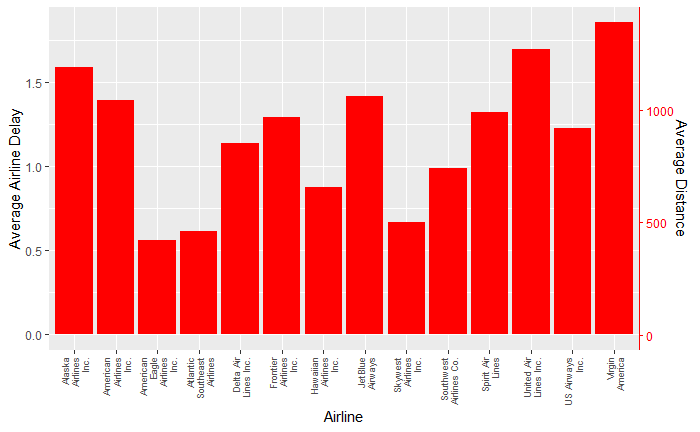

```r
#Airline inclination based on delay
library(ggplot2)
library(stringr)
flights.uncancelled <- flights[flights$CANCELLED == 0,]
flights.airline.delay <- flights.uncancelled %>% group_by(AIRLINE) %>% summarise(avg_delay = mean(AIRLINE_DELAY))
flights.airline.delay <- flights.airline.delay[order(flights.airline.delay$avg_delay),]

flights.distance <- flights.uncancelled %>% group_by(AIRLINE) %>% summarise(avg_distance = mean(DISTANCE))

ggplot() + geom_point(data=flights.airline.delay, aes(x=reorder(AIRLINE, avg_delay), y=avg_delay), color="black") + geom_bar(data=flights.distance, aes(x=AIRLINE, y=avg_distance/750), stat="identity",fill = "red") + scale_x_discrete(name="Airline",labels = function(x) str_wrap(x, width = 12)) + theme(axis.text.x = element_text(angle =90, vjust = 0.5, hjust=1, size=7)) +scale_y_continuous(name = 'Average Airline Delay', sec.axis = sec_axis(~. *750,name = "Average Distance")) + theme(axis.line.y.right = element_line(color = "red"), axis.ticks.y.right = element_line(color = "red"), axis.text.y.right = element_text(color = "red"))
```

## Part 2:

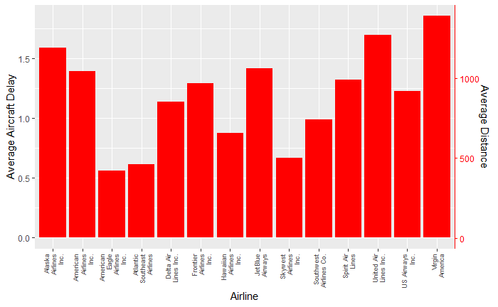

```r
flights.aircraft.delay <- flights.uncancelled %>% group_by(AIRLINE) %>% summarise(avg_delay = mean(LATE_AIRCRAFT_DELAY))
flights.aircraft.delay <- flights.aircraft.delay[order(flights.aircraft.delay$avg_delay),]

ggplot() + geom_point(data=flights.aircraft.delay, aes(x=reorder(AIRLINE, avg_delay), y=avg_delay), color="black") + geom_bar(data=flights.distance, aes(x=AIRLINE, y=avg_distance/750), stat="identity", fill="red") + scale_x_discrete(name="Airline",labels = function(x) str_wrap(x, width = 12)) + theme(axis.text.x = element_text(angle =90, vjust = 0.5, hjust=1, size=7)) +scale_y_continuous(name = 'Average Aircraft Delay', sec.axis = sec_axis(~. *750,name = "Average Distance"))+theme(axis.line.y.right = element_line(color = "red"), axis.ticks.y.right = element_line(color = "red"), axis.text.y.right = element_text(color = "red"))
```

## Part 2 Conclusion: Choose Hawaiian Airlines for shorter length flights, and Alaska Airlines for longer length flights. Avoid American Eagles for shorter flights and United Air Lines for longer flights

### Based on the results from the graph,

- We have identified Hawaiian Airlines for shorter length flights, since it has the lowest average aircraft delay given the average distance travelled, and Alaska Airlines for longer length flights, since it has the lowest average aircraft delay for its average distance travelled.
- We would also avoid American Eagle for shorter flights and United Air Lines for longer flights.

## Part 3:

## Part 3A:

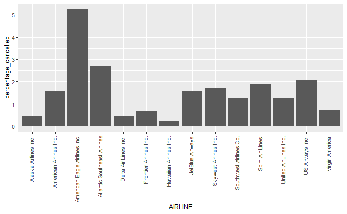

```r
airline_cancel <- flights %>% group_by(AIRLINE) %>% summarise(CANCELLED)
airline_cancel <- airline_cancel %>% count(CANCELLED == 1) %>% group_by(AIRLINE) %>% mutate(flights = sum(n)) %>% mutate(percentage_cancelled = (n/flights)*100) %>% filter(`CANCELLED == 1` == T)

ggplot(airline_cancel, aes(AIRLINE, percentage_cancelled)) + geom_col() + theme(text = element_text(size = 10), axis.text.x = element_text(angle = 90, hjust=0.95,vjust=0.2))
```

## Part 3B:

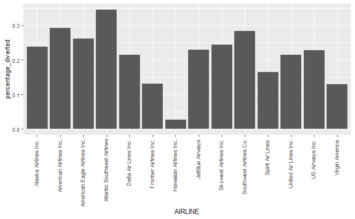

```r
diverted <- flights %>% group_by(AIRLINE) %>% summarise(DIVERTED)
diverted <- diverted %>% count(DIVERTED == 1) %>% group_by(AIRLINE) %>% mutate(flights = sum(n)) %>% mutate(percentage_diverted = (n/flights)*100) %>% filter(`DIVERTED == 1` == T)

ggplot(diverted, aes(AIRLINE, percentage_diverted)) + geom_col() + theme(text = element_text(size = 10), axis.text.x = element_text(angle = 90, hjust=0.95,vjust=0.2))
```

## Part 3B Conclusion: Avoid Atlantic Southeast Airlines (if emphasis is placed on diversion)

#### Based on the above charts,

- We have identified Atlantic Southeast Airlines as the option to avoid if the traveller’s main concern is for diverted flights.
- Atlantic Southeast Airlines has the highest percentage of diversion

## Part 3C:

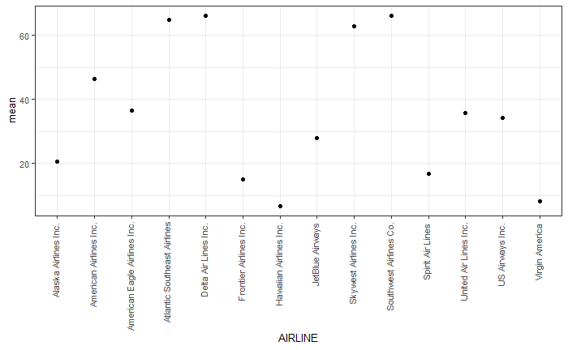

```r
daily <- flights[,c("date","AIRLINE")]
daily <- daily %>% group_by(AIRLINE,date) %>% mutate(count = n()) %>% arrange(date, AIRLINE) %>% summarise_all(last)
daily$date <- as.POSIXct(daily$date,format="%Y-%m-%d")

desti <- flights[,c("date","AIRLINE", "DESTINATION_AIRPORT")]
desti <- desti %>% group_by(date, AIRLINE) %>% arrange(AIRLINE) %>% distinct(DESTINATION_AIRPORT, .keep_all = T) %>% count('DESTINATION_AIRPORT') %>% group_by(AIRLINE) %>% mutate(mean = mean(n)) %>% summarise_all(first)

ggplot() + geom_point(data=desti,aes(x=AIRLINE, y = mean)) + theme_bw() + theme(text = element_text(size = 10), axis.text.x = element_text(angle = 90, hjust=0.95,vjust=0.2))
```

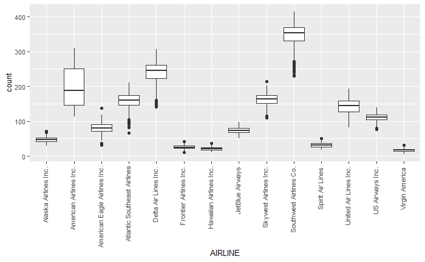

```r
ggplot() + geom_boxplot(data=daily, aes(x=AIRLINE, y=count)) + theme(text = element_text(size = 10), axis.text.x = element_text(angle = 90, hjust=0.95,vjust=0.2))
```

```r
# mean no. of destinations a day (dot) compared with the no. of flights a day (line)
```

#### Based on the above charts,

- We have identified Southwest Airlines as the option to choose if the traveller’s main concern is on flexibility of alternative is desired
- Southwest Airlines has the highest number of destination and number of flights daily

# Q2:Which airport to choose or avoid when travelling?

### To make a more informed decision on which airport to choose or avoid, we decided to base our analysis on several factors:

#### Part 1: Here are the factors used to decide which airport to choose:

- A potential traveler would prefer airports with more flight connections (ie. the number of destination airports that can be reached from the origin airport via a non-stop flight. )
- Avoid airports that are too crowded/ busy
- To strike a balance between the 2 factors above, we decided to choose an airport within the `Top 10 airports with the most flight connections` that isn’t in the `Top 10 airports with the most outbound flights`

#### Part 2: Here are the factors used to decide which airport to avoid:

#### Option 2A (If emphasis is placed on security):

- A reasonable traveler will attempt to avoid airports with a high frequency of security delay and high average duration for said delay
- To do so, we will be comparing the `Top 10 airports with the highest frequency of security delay` and the `Top 10 airports with the highest average security delay`

#### Option 2B (If emphasis is placed on airport delays):

- A reasonable traveler will attempt to avoid airports with a high frequency of air-system delay and high average duration for said delay
- To do so, we will be comparing the `Top 10 airports with the highest frequency of air system delay` and the `Top 10 airports with the highest average air system delay`

## Part 1:

```r
library(ggplot2)
library(ggmap)
library(conflicted)
conflict_prefer("select", "dplyr")
```

```
[conflicted] Removing existing preference
[conflicted] Will prefer dplyr::select over any other package
```

```r
conflict_prefer("filter", "dplyr")
```

```
[conflicted] Removing existing preference
[conflicted] Will prefer dplyr::filter over any other package
```

```r
# Finding airports with the highest number of outbound flights

numFlights <- flights %>% select(YEAR, MONTH, DAY, ORIGIN_AIRPORT, DESTINATION_AIRPORT)
numFlights <- numFlights %>% group_by(YEAR, MONTH, DAY, ORIGIN_AIRPORT) %>% summarise(outboundFlights = n())
numFlights <- numFlights %>% group_by(ORIGIN_AIRPORT) %>% summarise(avg.outboundFlights = round(mean(outboundFlights)))

topOutboundAirports <- numFlights[304:625,]
topOutboundAirports <- inner_join(topOutboundAirports, airports, by = c("ORIGIN_AIRPORT" = "IATA_CODE"))
topOutboundAirportsByRoutes <- topOutboundAirports %>% arrange(desc(avg.outboundFlights)) %>% slice(1:10)
```

## Top 10 airports with the highest number of outbound flights

```r
topOutboundAirportsByRoutes
```

| ORIGIN_AIRPORT | avg.outboundFlights | AIRPORT | CITY | STATE | COUNTRY | LATITUDE | LONGITUDE |
| --- | --- | --- | --- | --- | --- | --- | --- |
| ATL | 104 | Hartsfield-Jackson Atlanta International Airport | Atlanta | GA | USA | 33.64044 | -84.42694 |
| ORD | 85 | Chicago O'Hare International Airport | Chicago | IL | USA | 41.97960 | -87.90446 |
| DFW | 72 | Dallas/Fort Worth International Airport | Dallas-Fort Worth | TX | USA | 32.89595 | -97.03720 |
| DEN | 59 | Denver International Airport | Denver | CO | USA | 39.85841 | -104.66700 |
| LAX | 59 | Los Angeles International Airport | Los Angeles | CA | USA | 33.94254 | -118.40807 |
| IAH | 44 | George Bush Intercontinental Airport | Houston | TX | USA | 29.98047 | -95.33972 |
| PHX | 44 | Phoenix Sky Harbor International Airport | Phoenix | AZ | USA | 33.43417 | -112.00806 |
| SFO | 44 | San Francisco International Airport | San Francisco | CA | USA | 37.61900 | -122.37484 |
| LAS | 40 | McCarran International Airport | Las Vegas | NV | USA | 36.08036 | -115.15233 |
| MCO | 34 | Orlando International Airport | Orlando | FL | USA | 28.42889 | -81.31603 |

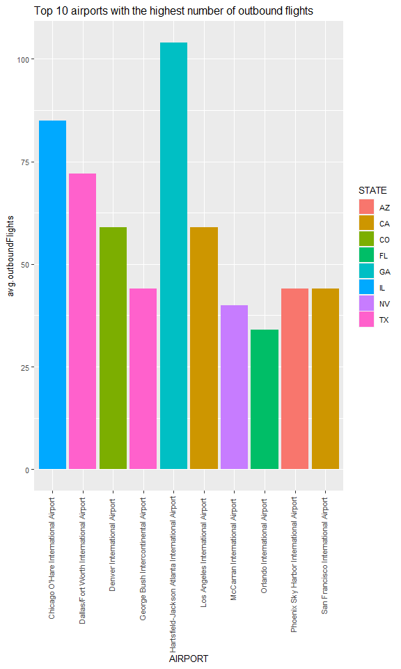

```r
outboundTopPlot <- ggplot(data=topOutboundAirportsByRoutes, aes(x=AIRPORT, y=avg.outboundFlights, fill=STATE)) + geom_bar(stat='identity') + theme(text = element_text(size = 10), axis.text.x = element_text(angle = 90, hjust=0.95,vjust=0.2))

print(outboundTopPlot + labs(title ="Top 10 airports with the highest number of outbound flights"))
```

```r
# Finding airports with the most number of flight connections

numFlightsCon <- flights %>% select(YEAR, MONTH, DAY, ORIGIN_AIRPORT, DESTINATION_AIRPORT) %>% distinct()
numFlightsCon <- numFlightsCon %>% group_by(YEAR, MONTH, DAY, ORIGIN_AIRPORT) %>% summarise(outboundRoutes = n())
numFlightsCon <- numFlightsCon %>% group_by(ORIGIN_AIRPORT) %>% summarise(avg.outboundRoutes = round(mean(outboundRoutes)))

AirportsWithMostRoutes <- numFlightsCon[304:625,]
AirportsWithMostRoutes <- inner_join(AirportsWithMostRoutes, airports, by = c("ORIGIN_AIRPORT" = "IATA_CODE"))
topAirportsWithMostRoutes <- AirportsWithMostRoutes %>% arrange(desc(avg.outboundRoutes)) %>% slice(1:10)
```

## Top 10 airports with the highest number of flight connections

```r
topAirportsWithMostRoutes
```

| ORIGIN_AIRPORT | avg.outboundRoutes | AIRPORT | CITY | STATE | COUNTRY | LATITUDE | LONGITUDE |
| --- | --- | --- | --- | --- | --- | --- | --- |
| ATL | 68 | Hartsfield-Jackson Atlanta International Airport | Atlanta | GA | USA | 33.64044 | -84.42694 |
| ORD | 57 | Chicago O'Hare International Airport | Chicago | IL | USA | 41.97960 | -87.90446 |
| DFW | 52 | Dallas/Fort Worth International Airport | Dallas-Fort Worth | TX | USA | 32.89595 | -97.03720 |
| DEN | 41 | Denver International Airport | Denver | CO | USA | 39.85841 | -104.66700 |
| IAH | 34 | George Bush Intercontinental Airport | Houston | TX | USA | 29.98047 | -95.33972 |
| LAX | 32 | Los Angeles International Airport | Los Angeles | CA | USA | 33.94254 | -118.40807 |
| PHX | 30 | Phoenix Sky Harbor International Airport | Phoenix | AZ | USA | 33.43417 | -112.00806 |
| LAS | 27 | McCarran International Airport | Las Vegas | NV | USA | 36.08036 | -115.15233 |
| SFO | 27 | San Francisco International Airport | San Francisco | CA | USA | 37.61900 | -122.37484 |
| MSP | 26 | Minneapolis-Saint Paul International Airport | Minneapolis | MN | USA | 44.88055 | -93.21692 |

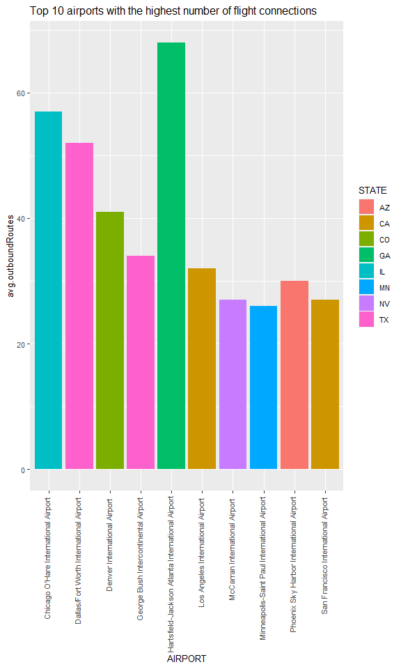

```r
routesTopPlot <- ggplot(data=topAirportsWithMostRoutes, aes(x=AIRPORT, y=avg.outboundRoutes, fill=STATE)) + geom_bar(stat='identity') + theme(text = element_text(size = 10), axis.text.x = element_text(angle = 90, hjust=0.95,vjust=0.2))

print(routesTopPlot + labs(title ="Top 10 airports with the highest number of flight connections"))
```

```r
# topOutboundAirportsByState <- topOutboundAirports %>% arrange(desc(avg.outboundFlights)) %>% group_by(STATE) %>% slice(1)
```

## Part 1 Conclusion: Choose Minneapolis-Saint Paul International Airport

### Based on the results from the 2 charts above,

- We have identified Minneapolis-Saint Paul International Airport in the state of to be the preferred airport to travel from as it was one of the Top 10 Airports with the most flight connection and yet, not one of the 10 busiest airport based on the average number of outbound flights per day.

## Part 2:

```r
# Airports with the most route offerings by state

AirportsWithMostRoutesByState <- AirportsWithMostRoutes %>% arrange(desc(avg.outboundRoutes)) %>% group_by(STATE) %>% slice(1)
AirportsWithMostRoutesByState <- AirportsWithMostRoutesByState[,c("AIRPORT", "CITY", "STATE", "avg.outboundRoutes")]
```

## Airports with the most route offerings by state

Here’s an extra table of the top airport in each state with the most flight connections. As such, if we have more specific profile data on who our potential traveller is and where he/she is from, we will likely recommend these airports based on the state he is currently in.

```r
AirportsWithMostRoutesByState
```

| AIRPORT | CITY | STATE | avg.outboundRoutes |
| --- | --- | --- | --- |
| Ted Stevens Anchorage International Airport | Anchorage | AK | 4 |
| Birmingham-Shuttlesworth International Airport | Birmingham | AL | 3 |
| Bill and Hillary Clinton National AirportÂ (Adams Field) | Little Rock | AR | 3 |
| Pago Pago International Airport (Tafuna Airport) | Pago Pago | AS | 1 |
| Phoenix Sky Harbor International Airport | Phoenix | AZ | 30 |
| Los Angeles International Airport | Los Angeles | CA | 32 |
| Denver International Airport | Denver | CO | 41 |
| Bradley International Airport | Windsor Locks | CT | 5 |
| Wilmington Airport | Wilmington | DE | 1 |
| Orlando International Airport | Orlando | FL | 24 |

[output cut: 44 more lines]

```r
NA
```

```r
# Finding airports with the highest average security delay (in minutes)

secDelay <- na.omit(flights) %>% select(YEAR, MONTH, DAY, ORIGIN_AIRPORT, SECURITY_DELAY)
secDelay <- secDelay %>% group_by(YEAR, MONTH, DAY, ORIGIN_AIRPORT) %>% summarise(securityDelay = sum(SECURITY_DELAY))
secDelay <- secDelay %>% group_by(ORIGIN_AIRPORT) %>% summarise(avg.secDelay = round(mean(securityDelay), digits = 3))

AirportsWithSecDelays <- secDelay[304:625,]
AirportsWithSecDelays <- inner_join(AirportsWithSecDelays, airports, by = c("ORIGIN_AIRPORT" = "IATA_CODE"))
topAirportsWithSecDelays <- AirportsWithSecDelays %>% arrange(desc(avg.secDelay)) %>% slice(2:11) %>% select(AIRPORT, avg.secDelay, CITY, STATE)

topAirportsWithSecDelays
```

| AIRPORT | avg.secDelay | CITY | STATE |
| --- | --- | --- | --- |
| Dallas/Fort Worth International Airport | 1.946 | Dallas-Fort Worth | TX |
| Phoenix Sky Harbor International Airport | 1.841 | Phoenix | AZ |
| Kodiak Airport | 1.600 | Kodiak | AK |
| John F. Kennedy International AirportÂ (New York International Airport) | 1.589 | New York | NY |
| Merle K. (Mudhole) Smith Airport | 1.500 | Cordova | AK |
| Charlotte Douglas International Airport | 1.470 | Charlotte | NC |
| Los Angeles International Airport | 1.048 | Los Angeles | CA |
| Philadelphia International Airport | 0.733 | Philadelphia | PA |
| Gen. Edward Lawrence Logan International Airport | 0.727 | Boston | MA |
| Petersburg James A. Johnson Airport | 0.724 | Petersburg | AK |

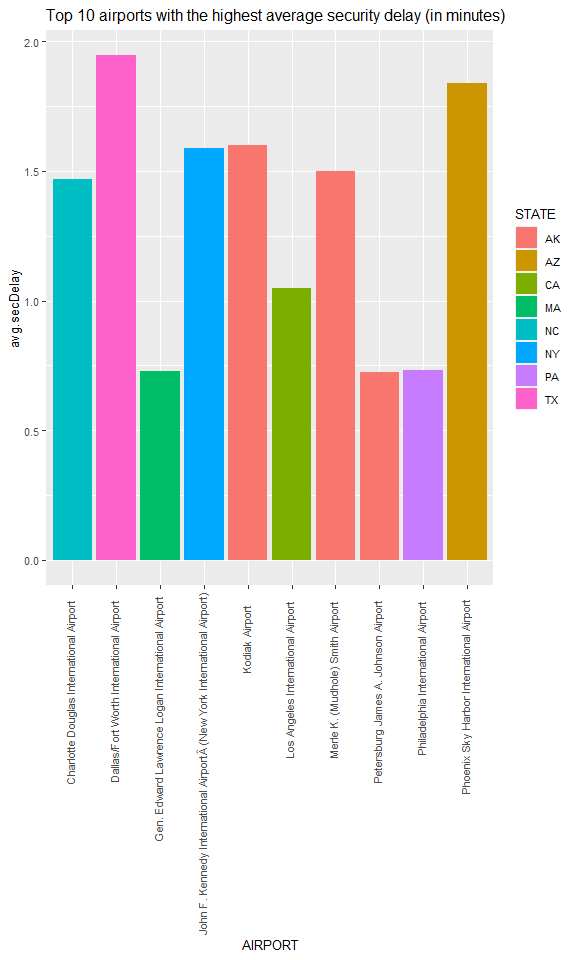

```r
secDelayTopPlot <- ggplot(data=topAirportsWithSecDelays, aes(x=AIRPORT, y=avg.secDelay, fill=STATE)) + geom_bar(stat='identity') + theme(text = element_text(size = 10), axis.text.x = element_text(angle = 90, hjust=0.95,vjust=0.2))

print(secDelayTopPlot + labs(title ="Top 10 airports with the highest average security delay (in minutes)"))
```

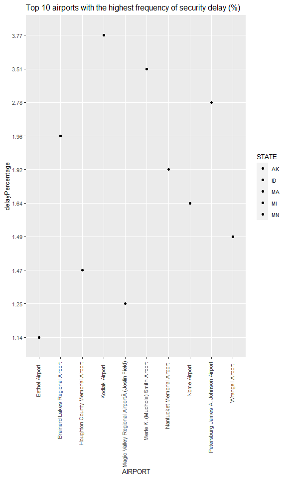

```r
library(imputeTS)

# Finding airports with the highest frequency of security delay (in minutes)

numFlights2 <- flights %>% group_by(ORIGIN_AIRPORT) %>% summarise(numOfFlights = n())
numFlights2 <- numFlights2[304:625,]

numOfSecDelay <- flights %>% filter(SECURITY_DELAY != 0) %>% group_by(ORIGIN_AIRPORT) %>% summarise(numSecDelays = n())
numOfSecDelay <- numOfSecDelay[10:87,]

combinedSecDelay <- merge(numFlights2, numOfSecDelay, by = "ORIGIN_AIRPORT", all.x = TRUE)
combinedSecDelay$numSecDelays <- na.replace(combinedSecDelay$numSecDelays, fill=0)
combinedSecDelay <- combinedSecDelay %>% mutate(delayPercentage = formatC((numSecDelays/numOfFlights)*100 , digits=2, format="f")) %>% arrange(desc(delayPercentage))


topCombinedSecDelay <- combinedSecDelay %>% slice(2:11) %>% inner_join(airports, by = c("ORIGIN_AIRPORT" = "IATA_CODE"))

secDelayTopFreqPlot <- ggplot(data=topCombinedSecDelay, aes(x=AIRPORT, y=delayPercentage, fill=STATE)) + geom_point(stat='identity') + theme(text = element_text(size = 10), axis.text.x = element_text(angle = 90, hjust=0.95,vjust=0.2))

print(secDelayTopFreqPlot + labs(title ="Top 10 airports with the highest frequency of security delay (%)"))
```

## Part 2B

```r
# Finding airports with the highest average air-system delay (in minutes)

airsysDelay <- na.omit(flights) %>% select(YEAR, MONTH, DAY, ORIGIN_AIRPORT, AIR_SYSTEM_DELAY)
airsysDelay <- airsysDelay %>% group_by(YEAR, MONTH, DAY, ORIGIN_AIRPORT) %>% summarise(airsysDelay = sum(AIR_SYSTEM_DELAY))
airsysDelay <- airsysDelay %>% group_by(ORIGIN_AIRPORT) %>% summarise(avg.airsysDelay = round(mean(airsysDelay), digits = 3))

AirportsWithAirSysDelays <- airsysDelay[304:625,]
AirportsWithAirSysDelays <- inner_join(AirportsWithAirSysDelays, airports, by = c("ORIGIN_AIRPORT" = "IATA_CODE"))
topAirportsWithAirSysDelays <- AirportsWithAirSysDelays %>% arrange(desc(avg.airsysDelay)) %>% slice(2:11) %>% select(AIRPORT, avg.airsysDelay, CITY, STATE)

topAirportsWithAirSysDelays
```

| AIRPORT | avg.airsysDelay | CITY | STATE |
| --- | --- | --- | --- |
| Hartsfield-Jackson Atlanta International Airport | 185.934 | Atlanta | GA |
| Denver International Airport | 165.961 | Denver | CO |
| Dallas/Fort Worth International Airport | 160.365 | Dallas-Fort Worth | TX |
| George Bush Intercontinental Airport | 133.278 | Houston | TX |
| Los Angeles International Airport | 126.302 | Los Angeles | CA |
| Gen. Edward Lawrence Logan International Airport | 123.171 | Boston | MA |
| LaGuardia Airport (Marine Air Terminal) | 113.213 | New York | NY |
| Orlando International Airport | 103.722 | Orlando | FL |
| John F. Kennedy International AirportÂ (New York International Airport) | 102.847 | New York | NY |
| Charlotte Douglas International Airport | 102.210 | Charlotte | NC |

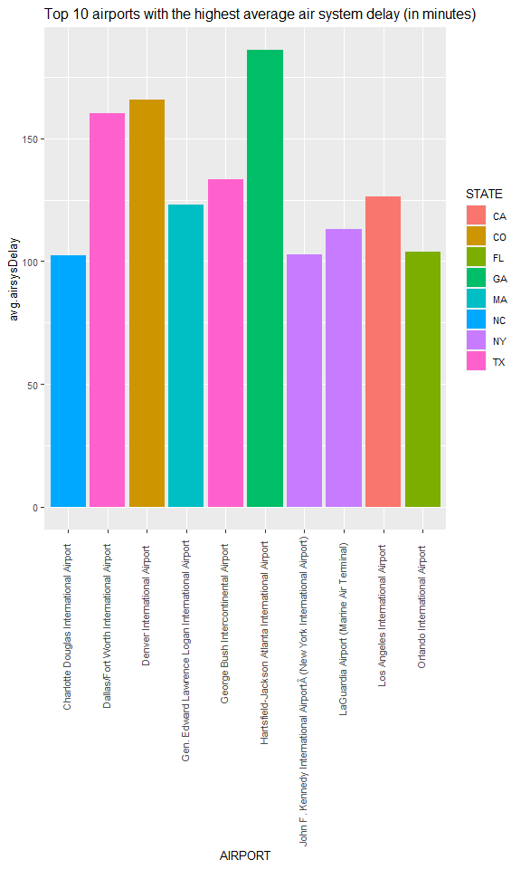

```r
airsysDelayTopPlot <- ggplot(data=topAirportsWithAirSysDelays, aes(x=AIRPORT, y=avg.airsysDelay, fill=STATE)) + geom_bar(stat='identity') + theme(text = element_text(size = 10), axis.text.x = element_text(angle = 90, hjust=0.95,vjust=0.2))

print(airsysDelayTopPlot + labs(title ="Top 10 airports with the highest average air system delay (in minutes)"))
```

```r
library(imputeTS)

# Finding airports with the highest frequency of air system delay (in minutes)

numFlights3 <- flights %>% group_by(ORIGIN_AIRPORT) %>% summarise(numOfFlights = n())
numFlights3 <- numFlights3[304:625,]

numOfAirSysDelay <- flights %>% filter(AIR_SYSTEM_DELAY != 0) %>% group_by(ORIGIN_AIRPORT) %>% summarise(numAirSysDelays = n())
numOfAirSysDelay <- numOfAirSysDelay[223:538,]

combinedAirSysDelay <- merge(numFlights3, numOfAirSysDelay, by = "ORIGIN_AIRPORT", all.x = TRUE)
combinedAirSysDelay$numAirSysDelays <- na.replace(combinedAirSysDelay$numAirSysDelays, fill=0)
combinedAirSysDelay <- combinedAirSysDelay %>% mutate(delayPercentage = formatC((numAirSysDelays/numOfFlights)*100 , digits=2, format="f")) %>% arrange(desc(delayPercentage))

combinedAirSysDelay
```

| ORIGIN_AIRPORT | numOfFlights | numAirSysDelays | delayPercentage |
| --- | --- | --- | --- |
| LAS | 13505 | 1346 | 9.97 |
| CRP | 502 | 50 | 9.96 |
| FLG | 182 | 18 | 9.89 |
| FLL | 7346 | 724 | 9.86 |
| DVL | 61 | 6 | 9.84 |
| CHA | 429 | 42 | 9.79 |
| LEX | 633 | 62 | 9.79 |
| MDT | 317 | 31 | 9.78 |
| ROC | 747 | 73 | 9.77 |
| BWI | 8594 | 831 | 9.67 |

[output cut: 312 more lines]

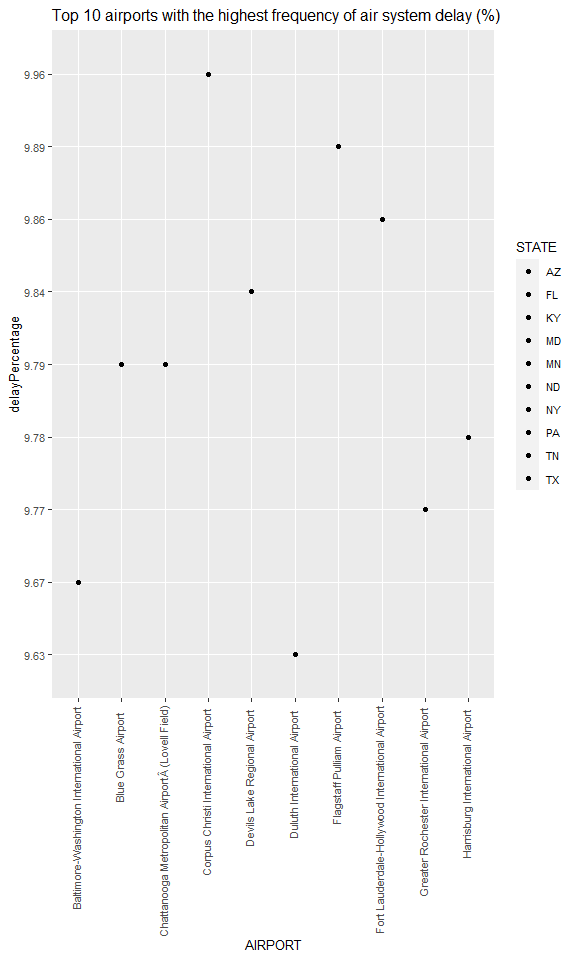

```r
topcombinedAirSysDelay <- combinedAirSysDelay %>% slice(2:11) %>% inner_join(airports, by = c("ORIGIN_AIRPORT" = "IATA_CODE"))

airSysDelayTopFreqPlot <- ggplot(data=topcombinedAirSysDelay, aes(x=AIRPORT, y=delayPercentage, fill=STATE)) + geom_point(stat='identity') + theme(text = element_text(size = 10), axis.text.x = element_text(angle = 90, hjust=0.95,vjust=0.2))

print(airSysDelayTopFreqPlot + labs(title ="Top 10 airports with the highest frequency of air system delay (%)"))
```

## Part 2B Conclusion: Avoid Corpus Christi International Airport (if emphasis is placed on air sys delay)

#### Based on the above charts,

- We have identified Corpus Christi International Airport as the option to avoid if the traveler’s main concern lies in the field of air system delay.
- Since there were no common airports within both charts above, we decided to prioritize the frequency of air system delay in our decision.

# Q3: What is the seasonal effect on flight performance?

#### Part 1: Weekend VS Weekdays

- A potential traveler might want to know whether it will be better to travel on weekends or weekdays
- Comparing the cancellation rates on weekends vs weekdays
- Comparing the delays on weekends vs weekdays

#### Part 2: Between different seasons

- A reasonable traveler might want to also know which season will be better for travelling.
- Comparing the cancellation rates in different seasons
- Comparing the delays in different seasons

#### Part 3: Effects of Holidays

- A reasonable traveller might want to know the effects of holiday.
- A reasonable traveler might want to also know which federal holidays will be better for travelling.
- Comparing the cancellation rates on different federal holidays, where we can observe which holidays are most prone to cancellations to avoid and which holidays to travel on given it has the least cancellations.
- Comparing the delays on different federal holidays, where we can observe which holidays are most prone to delays to avoid and which holidays to travel on given it has the least delays.

## Part 1: Weekend VS Weekdays

```r
library(ggplot2)
library(tidyr)
```

```r
#Data prep
weekend_vs_weekday <- flights %>% mutate(is_weekend = ifelse(.$DAY_OF_WEEK > 5, T, F), arrival_delayed = ifelse(.$ARRIVAL_DELAY > 0, T, F), departure_delayed = ifelse(.$DEPARTURE_DELAY > 0, T, F)) %>% filter(!is.na(ARRIVAL_DELAY) & !is.na(DEPARTURE_DELAY)) %>% group_by(is_weekend) %>% summarise(ave_arrival_delay = mean(ARRIVAL_DELAY), proportion_arrival_delay = mean(arrival_delayed), ave_departure_delay = mean(DEPARTURE_DELAY), proportion_departure_delay = mean(departure_delayed))
```

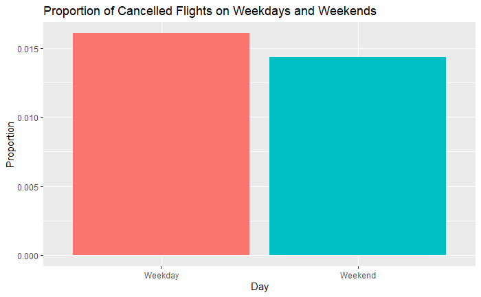

```r
#Graph 1
weekend_weekday_prop_cancelled <- flights %>% mutate(is_weekend = ifelse(.$DAY_OF_WEEK > 5, T, F)) %>% group_by(is_weekend) %>% summarise(proportion_cancelled = mean(CANCELLED))

ggplot(weekend_weekday_prop_cancelled, aes(is_weekend, proportion_cancelled, fill=is_weekend)) + geom_bar(stat='identity') + ggtitle("Proportion of Cancelled Flights on Weekdays and Weekends") + ylab("Proportion") +xlab("Day") + scale_x_discrete(labels=c("Weekday", "Weekend")) + theme(legend.position="none")
```

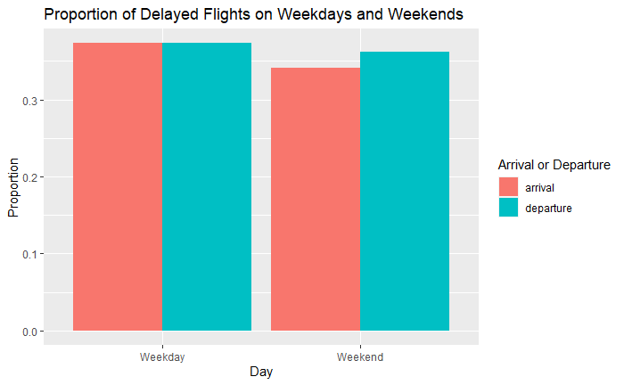

```r
#Graph 2
weekend_weekday_prop_delay <- weekend_vs_weekday %>% select(is_weekend, proportion_arrival_delay, proportion_departure_delay) %>% gather(key="departure_arrival", value="proportion", -1)
weekend_weekday_prop_delay$departure_arrival <- weekend_weekday_prop_delay$departure_arrival %>% {gsub("proportion_" , "", .)} %>% {gsub("_delay" , "", .)}

ggplot(data=weekend_weekday_prop_delay, aes(is_weekend, proportion, fill=departure_arrival)) + geom_bar(stat='identity', position='dodge') + ggtitle("Proportion of Delayed Flights on Weekdays and Weekends") + ylab("Proportion") +xlab("Day") + scale_x_discrete(labels=c("Weekday", "Weekend")) +  labs(fill="Arrival or Departure")
```

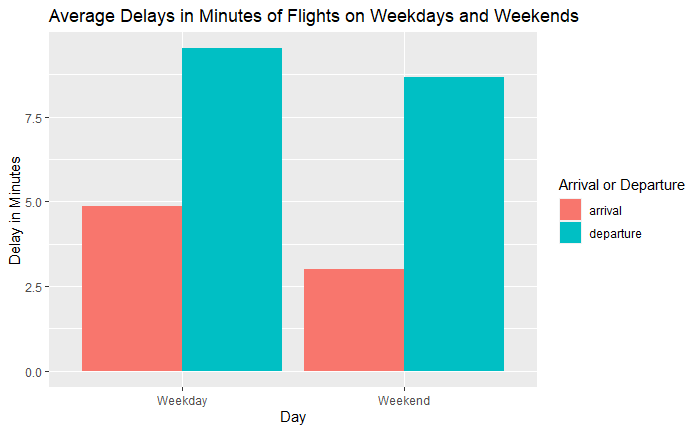

```r
#Graph 3
weekend_weekday_ave_delay <- weekend_vs_weekday %>% select(is_weekend, ave_arrival_delay, ave_departure_delay) %>% gather(key="departure_arrival", value="ave_delay", -1)
weekend_weekday_ave_delay$departure_arrival <- weekend_weekday_ave_delay$departure_arrival %>% {gsub("ave_" , "", .)} %>% {gsub("_delay" , "", .)}

ggplot(data=weekend_weekday_ave_delay, aes(is_weekend, ave_delay, fill=departure_arrival)) + geom_bar(stat='identity', position='dodge') + ggtitle("Average Delays in Minutes of Flights on Weekdays and Weekends") + ylab("Delay in Minutes") +xlab("Day") + scale_x_discrete(labels=c("Weekday", "Weekend")) +  labs(fill="Arrival or Departure")
```

## Part 2: Between different seasons

```r
#Data prep
spring <- as.POSIXlt("2015-03-20 00:00:00", format="%Y-%m-%d %H:%M:%S")
summer <- as.POSIXlt("2015-06-21 00:00:00", format="%Y-%m-%d %H:%M:%S")
autumn <- as.POSIXlt("2015-09-23 00:00:00", format="%Y-%m-%d %H:%M:%S")
winter <- as.POSIXlt("2015-12-21 00:00:00", format="%Y-%m-%d %H:%M:%S")

flights$SEASON <- ifelse(flights$SCHEDULED_DEPARTURE_TIME <= winter,
       ifelse(flights$SCHEDULED_DEPARTURE_TIME <= autumn,
       ifelse(flights$SCHEDULED_DEPARTURE_TIME <= summer,
       ifelse(flights$SCHEDULED_DEPARTURE_TIME <= spring, "Spring", "Winter"), "Summer"), "Autumn"), "Winter")


seasons <- flights %>% mutate(arrival_delayed = ifelse(.$ARRIVAL_DELAY > 0, T, F), departure_delayed = ifelse(.$DEPARTURE_DELAY > 0, T, F)) %>% filter(!is.na(ARRIVAL_DELAY) & !is.na(DEPARTURE_DELAY)) %>% group_by(SEASON) %>% summarise(ave_arrival_delay = mean(ARRIVAL_DELAY), proportion_arrival_delay = mean(arrival_delayed), ave_departure_delay = mean(DEPARTURE_DELAY), proportion_departure_delay = mean(departure_delayed))
```

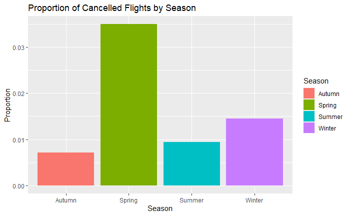

```r
#Graph 1
seasons_prop_cancelled <- flights %>% group_by(SEASON) %>% summarise(proportion_cancelled = mean(CANCELLED))

ggplot(seasons_prop_cancelled, aes(SEASON, proportion_cancelled, fill=SEASON)) + geom_bar(stat='identity') +ggtitle("Proportion of Cancelled Flights by Season") + ylab("Proportion") + xlab("Season") + labs(fill="Season")
```

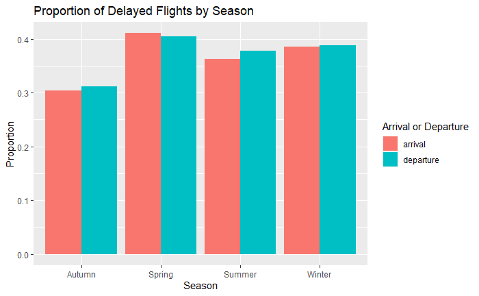

```r
#Graph 2
seasons_prop_delay <- seasons %>% select(SEASON, proportion_arrival_delay, proportion_departure_delay) %>% gather(key="departure_arrival", value="proportion", -1)
seasons_prop_delay$departure_arrival <- seasons_prop_delay$departure_arrival %>% {gsub("proportion_" , "", .)} %>% {gsub("_delay" , "", .)}

ggplot(data=seasons_prop_delay, aes(SEASON, proportion, fill=departure_arrival)) + geom_bar(stat='identity', position='dodge') + ggtitle("Proportion of Delayed Flights by Season") + ylab("Proportion") +xlab("Season") + labs(fill="Arrival or Departure")
```

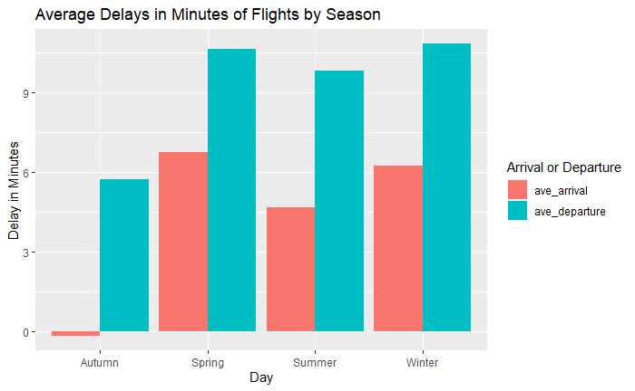

```r
#Graph 3
seasons_ave_delay <- seasons %>% select(SEASON, ave_arrival_delay, ave_departure_delay) %>% gather(key="departure_arrival", value="ave_delay", -1)
seasons_ave_delay$departure_arrival <- seasons_ave_delay$departure_arrival %>% {gsub("proportion_" , "", .)} %>% {gsub("_delay" , "", .)}

ggplot(data=seasons_ave_delay, aes(SEASON, ave_delay, fill=departure_arrival)) + geom_bar(stat='identity', position='dodge') + ggtitle("Average Delays in Minutes of Flights by Season") + ylab("Delay in Minutes") +xlab("Day") +  labs(fill="Arrival or Departure")
```

## Part 3: Effects of Holidays

# Holiday vs Not Holiday

```r
#Data collection/Data prep

library(XML)
url <- "https://www.timeanddate.com/holidays/us/2015"
html <- readLines(url)
holiday_table <- readHTMLTable(html)[[1]]

federal_holidays <- holiday_table %>% drop_na() %>% filter(V4 == "Federal Holiday") %>% distinct() %>% select(V3, V4)
colnames(federal_holidays) <- c("Holiday", "Type")

all_holiday_table <- holiday_table %>% drop_na() %>% select(V1, V2, V3)
colnames(all_holiday_table) <- c("Holiday_Date", "Day", "Holiday")
all_holiday_table$Holiday_Date <- all_holiday_table$Holiday_Date %>% paste("2015") %>% as.Date(format="%d %b %Y")
all_holiday_table <- all_holiday_table %>% distinct()

flights$date <- flights$date %>% as.Date(format="%Y-%m-%d")
flights <- flights %>% left_join(all_holiday_table, by=c("date" = "Holiday_Date"))
flights <- flights %>% left_join(federal_holidays)
federal_holidays <- flights %>% mutate(arrival_delayed = ifelse(.$ARRIVAL_DELAY > 0, T, F), departure_delayed = ifelse(.$DEPARTURE_DELAY > 0, T, F)) %>% filter(!is.na(ARRIVAL_DELAY) & !is.na(DEPARTURE_DELAY) & Type == "Federal Holiday") %>% group_by(Holiday) %>% summarise(ave_arrival_delay = mean(ARRIVAL_DELAY), proportion_arrival_delay = mean(arrival_delayed), ave_departure_delay = mean(DEPARTURE_DELAY), proportion_departure_delay = mean(departure_delayed))

#Data prep

holiday_vs_not <- flights %>% mutate(is_holiday = ifelse(!is.na(.$Holiday), T, F), arrival_delayed = ifelse(.$ARRIVAL_DELAY > 0, T, F), departure_delayed = ifelse(.$DEPARTURE_DELAY > 0, T, F)) %>% filter(!is.na(ARRIVAL_DELAY) & !is.na(DEPARTURE_DELAY)) %>% group_by(is_holiday) %>% summarise(ave_arrival_delay = mean(ARRIVAL_DELAY), proportion_arrival_delay = mean(arrival_delayed), ave_departure_delay = mean(DEPARTURE_DELAY), proportion_departure_delay = mean(departure_delayed))
```

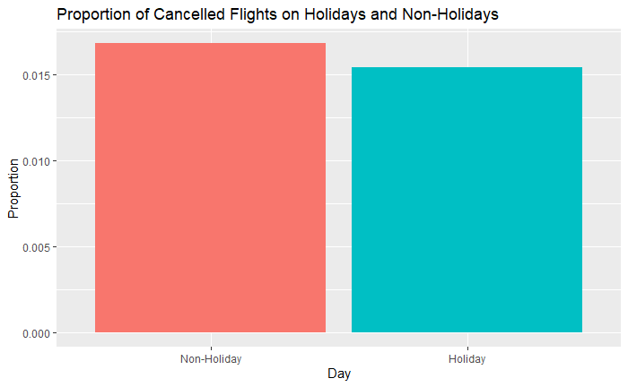

```r
#Graph 1

holiday_not_prop_cancelled <- flights %>% mutate(is_holiday = ifelse(!is.na(.$Holiday), T, F)) %>% group_by(is_holiday) %>% summarise(proportion_cancelled = mean(CANCELLED))

ggplot(holiday_not_prop_cancelled, aes(is_holiday, proportion_cancelled, fill=is_holiday)) + geom_bar(stat='identity') + ggtitle("Proportion of Cancelled Flights on Holidays and Non-Holidays") + ylab("Proportion") +xlab("Day") + scale_x_discrete(labels=c("Non-Holiday", "Holiday")) + theme(legend.position="none")
```

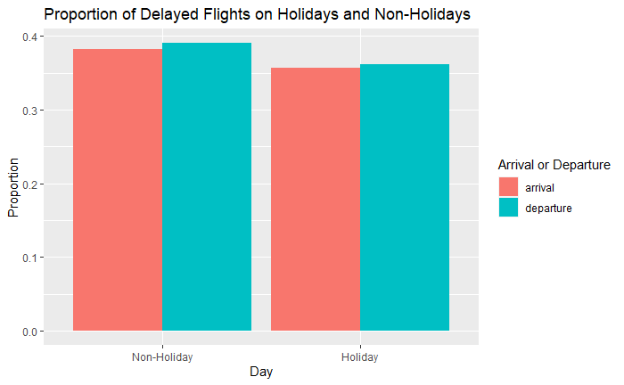

```r
#Graph 2

holiday_not_prop_delay <- holiday_vs_not %>% select(is_holiday, proportion_arrival_delay, proportion_departure_delay) %>% gather(key="departure_arrival", value="proportion", -1)
holiday_not_prop_delay$departure_arrival <- holiday_not_prop_delay$departure_arrival %>% {gsub("proportion_" , "", .)} %>% {gsub("_delay" , "", .)}

ggplot(data=holiday_not_prop_delay, aes(is_holiday, proportion, fill=departure_arrival)) + geom_bar(stat='identity', position='dodge')  + ggtitle("Proportion of Delayed Flights on Holidays and Non-Holidays") + ylab("Proportion") +xlab("Day") + scale_x_discrete(labels=c("Non-Holiday", "Holiday")) +  labs(fill="Arrival or Departure")
```

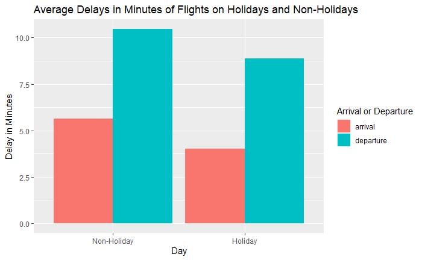

```r
#Graph 3

holiday_not_ave_delay <- holiday_vs_not %>% select(is_holiday, ave_arrival_delay, ave_departure_delay) %>% gather(key="departure_arrival", value="ave_delay", -1)
holiday_not_ave_delay$departure_arrival <- holiday_not_ave_delay$departure_arrival %>% {gsub("ave_" , "", .)} %>% {gsub("_delay" , "", .)}

ggplot(data=holiday_not_ave_delay, aes(is_holiday, ave_delay, fill=departure_arrival)) + geom_bar(stat='identity', position='dodge') + ggtitle("Average Delays in Minutes of Flights on Holidays and Non-Holidays") + ylab("Delay in Minutes") +xlab("Day") + scale_x_discrete(labels=c("Non-Holiday", "Holiday")) +  labs(fill="Arrival or Departure")
```

## Which holiday?

```r
library(XML)
library(stringr)
```

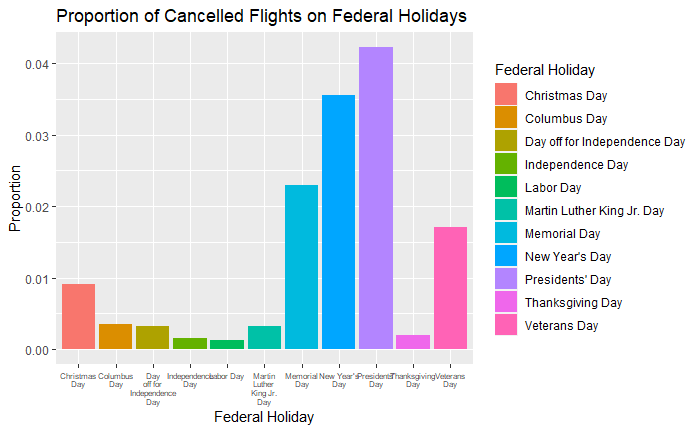

```r
#Graph 1
federal_holidays_prop_cancelled <- flights %>% filter(Type == "Federal Holiday") %>% group_by(Holiday) %>% summarise(proportion_cancelled = mean(CANCELLED))

ggplot(federal_holidays_prop_cancelled, aes(Holiday, proportion_cancelled, fill=Holiday)) + geom_bar(stat='identity') + scale_x_discrete(labels= function(x) str_wrap(x, width=10)) + theme(axis.text.x= element_text(size=6)) + ggtitle("Proportion of Cancelled Flights on Federal Holidays") + ylab("Proportion") + xlab("Federal Holiday") + labs(fill="Federal Holiday")
```

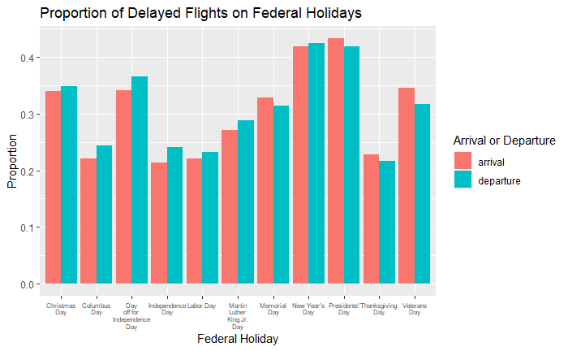

```r
#Graph 2

federal_holidays_prop_delay <- federal_holidays %>% select(Holiday, proportion_arrival_delay, proportion_departure_delay) %>% gather(key="departure_arrival", value="proportion", -1)
federal_holidays_prop_delay$departure_arrival <- federal_holidays_prop_delay$departure_arrival %>% {gsub("proportion_" , "", .)} %>% {gsub("_delay" , "", .)}

ggplot(data=federal_holidays_prop_delay, aes(Holiday, proportion, fill=departure_arrival)) + geom_bar(stat='identity', position='dodge') + scale_x_discrete(labels= function(x) str_wrap(x, width=10)) + theme(axis.text.x= element_text(size=6)) + ggtitle("Proportion of Delayed Flights on Federal Holidays") + ylab("Proportion") +xlab("Federal Holiday") + labs(fill="Arrival or Departure")
```

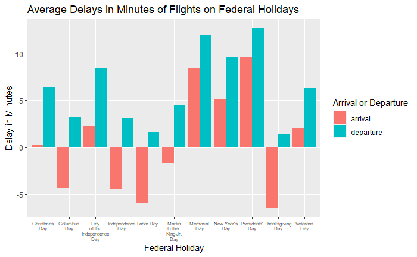

```r
#Graph 3
federal_holidays_ave_delay <- federal_holidays %>% select(Holiday, ave_arrival_delay, ave_departure_delay) %>% gather(key="departure_arrival", value="ave_delay", -1)
federal_holidays_ave_delay$departure_arrival <- federal_holidays_ave_delay$departure_arrival %>% {gsub("ave_" , "", .)} %>% {gsub("_delay" , "", .)}

ggplot(data=federal_holidays_ave_delay, aes(Holiday, ave_delay, fill=departure_arrival)) + geom_bar(stat='identity', position='dodge') + scale_x_discrete(labels= function(x) str_wrap(x, width=10)) + theme(axis.text.x= element_text(size=6)) + ggtitle("Average Delays in Minutes of Flights on Federal Holidays") + ylab("Delay in Minutes") +xlab("Federal Holiday") +  labs(fill="Arrival or Departure")
```

# Question 4: Visualizing data with map

```r
library(leaflet)
library(dplyr)
library(raster)

# states <- unique(airports[,"STATE"])

# Map of all airports with radius size representing the number of outbound routes offered by the airport

map <- leaflet() %>% addTiles() %>% addCircleMarkers(data = AirportsWithMostRoutes, lat = ~LATITUDE, lng = ~LONGITUDE, popup = ~AIRPORT, radius = ~avg.outboundRoutes, clusterOptions = markerClusterOptions())
map <- addTiles(map,group="Default")
map <- addProviderTiles(map,"Esri.WorldImagery", group = "Esri")
map <- addProviderTiles(map,"Stamen.Toner", group = "Toner")
map <- addProviderTiles(map, "Stamen.TonerLite", group = "Toner Lite")
map <- addLayersControl(map, baseGroups = c("Default","Esri",
                                        "Toner Lite","Toner"),
)
```

## Map of all airports with radius size representing the number of outbound routes offered (Airports offering more flight connections will have a larger radius)

#### Zoom in to view individual airports

```r
map
```

[interactive chart not shown]

```r
library(leaflet.extras)

# Heatmap of airports with intensities based on the percentage of security delays
options("viewer" = function(url, ...) utils::browseURL(url))
combinedSecDelay <- combinedSecDelay %>% inner_join(airports, by = c("ORIGIN_AIRPORT" = "IATA_CODE")) %>% na.omit()
map2<-leaflet(combinedSecDelay) %>% addProviderTiles(providers$CartoDB.DarkMatter) %>%
  addHeatmap(lng=~LONGITUDE, lat=~LATITUDE, intensity = ~delayPercentage, blur = 15, radius = 8)
```

## Heatmap of airports with intensities based on the percentage of security delays

```r
map2
```

[interactive chart not shown]

```r
# Heatmap of airports with intensities based on the number of outbound flights in total
options("viewer" = function(url, ...) utils::browseURL(url))
# combinedSecDelay <- combinedSecDelay %>% inner_join(airports, by = c("ORIGIN_AIRPORT" = "IATA_CODE")) %>% na.omit()
map3<-leaflet(combinedSecDelay) %>% addProviderTiles(providers$CartoDB.DarkMatter) %>%
  addHeatmap(lng=~LONGITUDE, lat=~LATITUDE, intensity = ~numOfFlights*1000, blur = 15, radius = 8)
```

## Heatmap of airports with intensities based on the number of outbound flights in total

```r
map3
```

[interactive chart not shown]

# Extra Question:

## Which routes should we avoid when travelling?

### Approach for our answer: We should avoid routes with the highest frequency of delays

```r
library(dplyr)
library(geosphere)
library(leaflet)

routesDelay <- na.omit(flights) %>% filter(ARRIVAL_DELAY > 0)
routesDelay <- routesDelay[,c("ORIGIN_AIRPORT", "DESTINATION_AIRPORT", "ARRIVAL_DELAY")] %>% group_by(ORIGIN_AIRPORT,DESTINATION_AIRPORT) %>% summarise(delayCount = n())
routesDelay <- routesDelay[136:1674,]

routesTotal <- na.omit(flights)
routesTotal <- routesTotal[,c("ORIGIN_AIRPORT", "DESTINATION_AIRPORT", "ARRIVAL_DELAY")] %>% group_by(ORIGIN_AIRPORT,DESTINATION_AIRPORT) %>% summarise(count = n())
routesTotal <- routesTotal[3780:8281,]

combinedRoutes <- inner_join(routesDelay, routesTotal)
combinedRoutes <- mutate(combinedRoutes, percentageOfDelay = round((delayCount/count)*100, digits = 1))
topDelayedRoutes <- combinedRoutes %>% arrange(desc(percentageOfDelay))

# Since the top 10 most frequently delayed routes at this point had less than 10 flights in the entire year, the data will likely be inaccurate due to the small sample size and insignificant as these are likely unpopular routes.

# Hence, we decided to filter routes with only more than 12 flights (on average 1 flight per month)

topDelayedRoutes <- topDelayedRoutes %>% filter(count >= 12) %>% head(10)
```

## Table of the top 10 most delayed flight routes

```r
topDelayedRoutes
```

| ORIGIN_AIRPORT | DESTINATION_AIRPORT | delayCount | count | percentageOfDelay |
| --- | --- | --- | --- | --- |
| SFO | DEN | 6 | 14 | 42.9 |
| SJU | JFK | 5 | 12 | 41.7 |
| SLC | DEN | 6 | 18 | 33.3 |
| SEA | DEN | 5 | 16 | 31.2 |
| SAN | SFO | 4 | 17 | 23.5 |
| SNA | DEN | 3 | 13 | 23.1 |
| SFO | SEA | 4 | 19 | 21.1 |
| RSW | ATL | 3 | 15 | 20.0 |
| SLC | LAX | 3 | 15 | 20.0 |
| SEA | ANC | 3 | 16 | 18.8 |

```r
topDelayedRoutes <- inner_join(topDelayedRoutes, airports, by= c("ORIGIN_AIRPORT" = "IATA_CODE"))
topDelayedRoutes <- inner_join(topDelayedRoutes, airports, by= c("DESTINATION_AIRPORT" = "IATA_CODE"))

topDelayedRoutesPlot <-gcIntermediate(as.matrix(topDelayedRoutes[,c("LONGITUDE.x", "LATITUDE.x")]),
                        as.matrix(topDelayedRoutes[,c("LONGITUDE.y", "LATITUDE.y")]),
                        n=100,
                        addStartEnd=TRUE,
                        sp=TRUE,
                        breakAtDateLine=FALSE) %>% leaflet() %>% addTiles() %>% addPolylines(weight = 1, opacity = 0.8, color = "#820a0a") %>% addCircleMarkers(data = topDelayedRoutes, lat = ~LATITUDE.x, lng = ~LONGITUDE.x, popup = ~AIRPORT.x, radius = 0.5) %>% addCircleMarkers(data = topDelayedRoutes, lat = ~LATITUDE.y, lng = ~LONGITUDE.y, popup = ~AIRPORT.y, radius = 0.5)
```

## Plot of the top 10 most frequently delayed flight routes (click on circle markers to view airport names)

```r
topDelayedRoutesPlot
```

[interactive chart not shown]